# Final Project Analysis

Yihong Deng

2025-05-14

# Introduction

Wine quality assessment is traditionally performed by human experts through sensory evaluation, which can be subjective and resource-intensive. Developing objective models to predict wine quality based on physicochemical properties would enable more consistent quality control and potentially optimize production processes. This project investigated how specific chemical attributes of red wine influence its quality ratings and developed a predictive model that could assist winemakers in production decisions.

## Dataset Description

This analysis uses the “Red Wine Quality” dataset from Kaggle [1], which contains physicochemical properties and quality ratings for red wine variants of Portuguese “Vinho Verde” wine. The dataset was originally collected by P. Cortez et al. (2009) [2] and made available through the UCI Machine Learning Repository. It includes:

- 11 physicochemical input variables (including acidity, pH, alcohol content, etc.)
- 1 output variable (quality rating, scored between 0 and 10)
- 1,599 observations

The key research question is: **How do chemical attributes such as alcohol content, volatile acidity, and sulphates influence the quality of red wine, and can these predictors be used to build a reliable predictive model for wine quality?**

# Methods

I analyzed a wine quality dataset to understand how chemical properties affect wine ratings. After examining the data for missing values and checking distributions, I created scatterplots to explore relationships between quality and key variables like alcohol and acidity. I then built several linear regression models, starting with a simple model and expanding to include multiple predictors and interaction effects. To ensure my analysis was statistically sound, I checked the regression assumptions using residual plots and statistical tests. When I found issues like heteroscedasticity, I used robust standard errors and log transformations to correct them. I also applied forward and backward selection techniques to identify the most important chemical properties affecting wine quality, comparing the results using AIC and BIC criteria.

# Data Analysis

##Data Loading and Inspection

```r
wine_data <- read.csv("https://drive.google.com/uc?id=1UCrzhWxCZsEXSwV7bZ19Vq77ma2KWvbR")
str(wine_data)
```

```
## 'data.frame':    1599 obs. of  12 variables:
##  $ fixed.acidity       : num  7.4 7.8 7.8 11.2 7.4 7.4 7.9 7.3 7.8 7.5 ...
##  $ volatile.acidity    : num  0.7 0.88 0.76 0.28 0.7 0.66 0.6 0.65 0.58 0.5 ...
##  $ citric.acid         : num  0 0 0.04 0.56 0 0 0.06 0 0.02 0.36 ...
##  $ residual.sugar      : num  1.9 2.6 2.3 1.9 1.9 1.8 1.6 1.2 2 6.1 ...
##  $ chlorides           : num  0.076 0.098 0.092 0.075 0.076 0.075 0.069 0.065 0.073 0.071 ...
##  $ free.sulfur.dioxide : num  11 25 15 17 11 13 15 15 9 17 ...
##  $ total.sulfur.dioxide: num  34 67 54 60 34 40 59 21 18 102 ...
##  $ density             : num  0.998 0.997 0.997 0.998 0.998 ...
##  $ pH                  : num  3.51 3.2 3.26 3.16 3.51 3.51 3.3 3.39 3.36 3.35 ...
##  $ sulphates           : num  0.56 0.68 0.65 0.58 0.56 0.56 0.46 0.47 0.57 0.8 ...
##  $ alcohol             : num  9.4 9.8 9.8 9.8 9.4 9.4 9.4 10 9.5 10.5 ...
##  $ quality             : int  5 5 5 6 5 5 5 7 7 5 ...
```

```r
head(wine_data)
```

```
##   fixed.acidity volatile.acidity citric.acid residual.sugar chlorides
## 1           7.4             0.70        0.00            1.9     0.076
## 2           7.8             0.88        0.00            2.6     0.098
## 3           7.8             0.76        0.04            2.3     0.092
## 4          11.2             0.28        0.56            1.9     0.075
## 5           7.4             0.70        0.00            1.9     0.076
## 6           7.4             0.66        0.00            1.8     0.075
##   free.sulfur.dioxide total.sulfur.dioxide density   pH sulphates alcohol
## 1                  11                   34  0.9978 3.51      0.56     9.4
## 2                  25                   67  0.9968 3.20      0.68     9.8
## 3                  15                   54  0.9970 3.26      0.65     9.8
## 4                  17                   60  0.9980 3.16      0.58     9.8
## 5                  11                   34  0.9978 3.51      0.56     9.4
## 6                  13                   40  0.9978 3.51      0.56     9.4
##   quality
## 1       5
## 2       5
## 3       5
## 4       6
## 5       5
## 6       5
```

```r
summary(wine_data)
```

```
##  fixed.acidity   volatile.acidity  citric.acid    residual.sugar
##  Min.   : 4.60   Min.   :0.1200   Min.   :0.000   Min.   : 0.900
##  1st Qu.: 7.10   1st Qu.:0.3900   1st Qu.:0.090   1st Qu.: 1.900
##  Median : 7.90   Median :0.5200   Median :0.260   Median : 2.200
##  Mean   : 8.32   Mean   :0.5278   Mean   :0.271   Mean   : 2.539
##  3rd Qu.: 9.20   3rd Qu.:0.6400   3rd Qu.:0.420   3rd Qu.: 2.600
##  Max.   :15.90   Max.   :1.5800   Max.   :1.000   Max.   :15.500
##    chlorides       free.sulfur.dioxide total.sulfur.dioxide    density
##  Min.   :0.01200   Min.   : 1.00       Min.   :  6.00       Min.   :0.9901
##  1st Qu.:0.07000   1st Qu.: 7.00       1st Qu.: 22.00       1st Qu.:0.9956
##  Median :0.07900   Median :14.00       Median : 38.00       Median :0.9968
##  Mean   :0.08747   Mean   :15.87       Mean   : 46.47       Mean   :0.9967
##  3rd Qu.:0.09000   3rd Qu.:21.00       3rd Qu.: 62.00       3rd Qu.:0.9978
##  Max.   :0.61100   Max.   :72.00       Max.   :289.00       Max.   :1.0037
##        pH          sulphates         alcohol         quality
##  Min.   :2.740   Min.   :0.3300   Min.   : 8.40   Min.   :3.000
##  1st Qu.:3.210   1st Qu.:0.5500   1st Qu.: 9.50   1st Qu.:5.000
##  Median :3.310   Median :0.6200   Median :10.20   Median :6.000
##  Mean   :3.311   Mean   :0.6581   Mean   :10.42   Mean   :5.636
##  3rd Qu.:3.400   3rd Qu.:0.7300   3rd Qu.:11.10   3rd Qu.:6.000
##  Max.   :4.010   Max.   :2.0000   Max.   :14.90   Max.   :8.000
```

##Missing Values and Data Completeness

```r
missing_values <- colSums(is.na(wine_data))
print(missing_values)
```

```
##        fixed.acidity     volatile.acidity          citric.acid
##                    0                    0                    0
##       residual.sugar            chlorides  free.sulfur.dioxide
##                    0                    0                    0
## total.sulfur.dioxide              density                   pH
##                    0                    0                    0
##            sulphates              alcohol              quality
##                    0                    0                    0
```

```r
vars <- c("alcohol", "volatile.acidity", "sulphates", "quality")
for (var in vars) {
  if (any(is.na(wine_data[[var]]))) {
    cat("Imputing missing values for variable:", var, "\n")
    wine_data[[var]][is.na(wine_data[[var]])] <- mean(wine_data[[var]], na.rm = TRUE)
  }
}
```

##Distribution of Key Variables

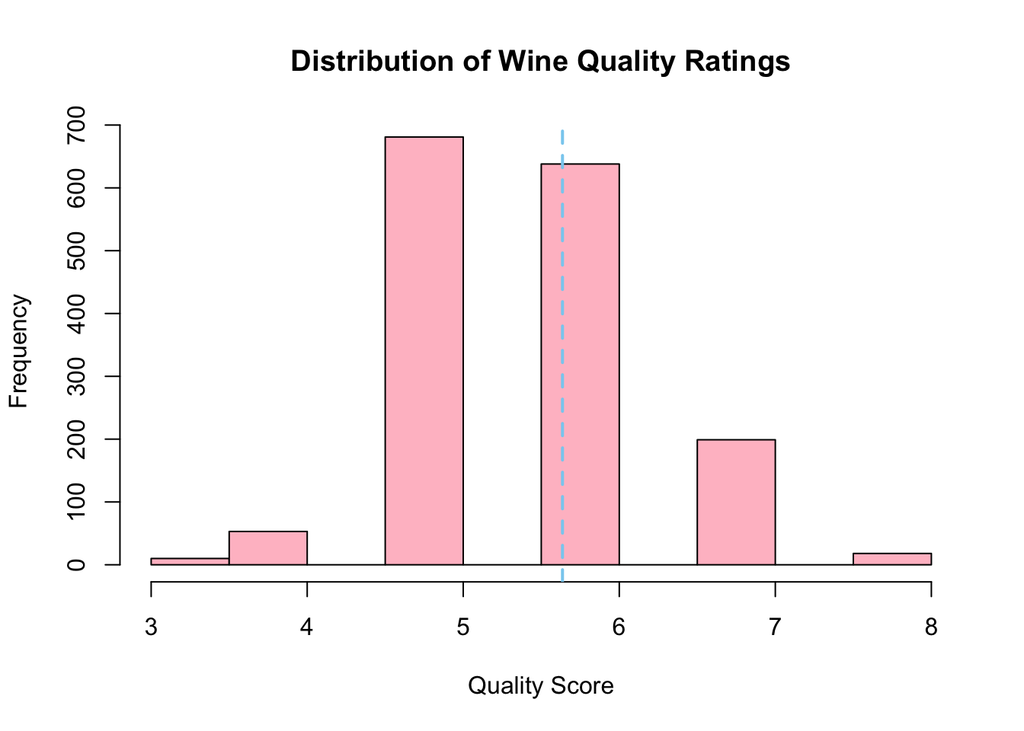

```r
hist(wine_data$quality,
     main = "Distribution of Wine Quality Ratings",
     xlab = "Quality Score",
     col = "pink",
     breaks = 10)
abline(v = mean(wine_data$quality), col = "#89CFF0", lwd = 2, lty = 2)
```

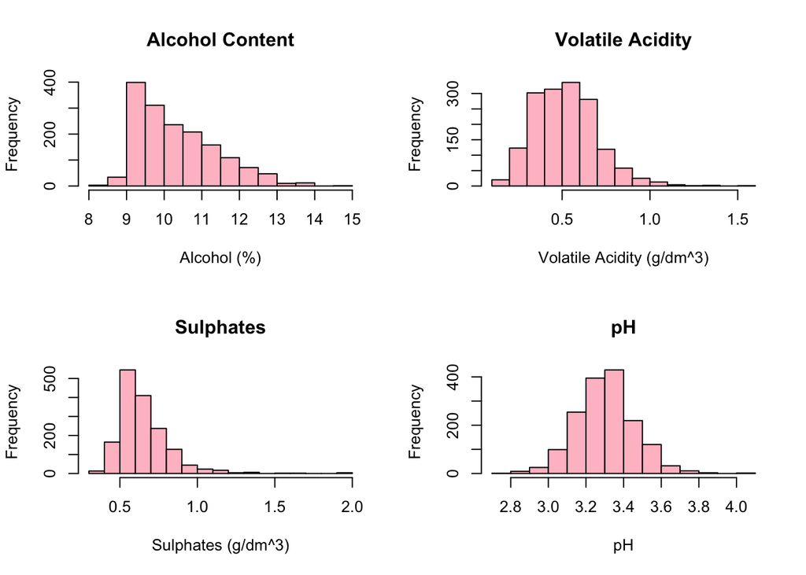

```r
# Histograms of key predictors
par(mfrow = c(2, 2))
hist(wine_data$alcohol,
     main = "Alcohol Content", xlab = "Alcohol (%)", col = "pink")
hist(wine_data$volatile.acidity,
     main = "Volatile Acidity", xlab = "Volatile Acidity (g/dm^3)", col = "pink")
hist(wine_data$sulphates,
     main = "Sulphates", xlab = "Sulphates (g/dm^3)", col = "pink")
hist(wine_data$pH,
     main = "pH", xlab = "pH", col = "pink")
```

```r
par(mfrow = c(1, 1))
```

The quality scores range from 3 to 8, with most wines rated between 5 and 6. The mean quality score is 5.64.

##Relationships Between Variables

```r
# Calculate individual correlations
cor_alcohol <- cor(wine_data$alcohol, wine_data$quality)
cor_volatile <- cor(wine_data$volatile.acidity, wine_data$quality)
cor_sulphates <- cor(wine_data$sulphates, wine_data$quality)


cat("Correlation between quality and alcohol:", round(cor_alcohol, 3), "\n")
```

```
## Correlation between quality and alcohol: 0.476
```

```r
cat("Correlation between quality and volatile acidity:", round(cor_volatile, 3), "\n")
```

```
## Correlation between quality and volatile acidity: -0.391
```

```r
cat("Correlation between quality and sulphates:", round(cor_sulphates, 3), "\n")
```

```
## Correlation between quality and sulphates: 0.251
```

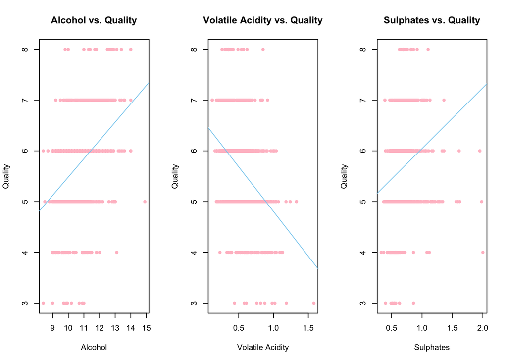

```r
# Create individual scatterplots
par(mfrow = c(1, 3))
plot(wine_data$alcohol, wine_data$quality,
     main = "Alcohol vs. Quality",
     xlab = "Alcohol", ylab = "Quality",
     pch = 19, col = "pink", cex = 0.7)
abline(lm(quality ~ alcohol, data = wine_data), col = "#89CFF0")

plot(wine_data$volatile.acidity, wine_data$quality,
     main = "Volatile Acidity vs. Quality",
     xlab = "Volatile Acidity", ylab = "Quality",
     pch = 19, col = "pink", cex = 0.7)
abline(lm(quality ~ volatile.acidity, data = wine_data), col = "#89CFF0")

plot(wine_data$sulphates, wine_data$quality,
     main = "Sulphates vs. Quality",
     xlab = "Sulphates", ylab = "Quality",
     pch = 19, col = "pink", cex = 0.7)
abline(lm(quality ~ sulphates, data = wine_data), col = "#89CFF0")
```

```r
par(mfrow = c(1, 1))
```

The correlation coefficients show that alcohol has a positive correlation with quality (r = 0.48), volatile acidity has a negative correlation with quality (r = -0.39), and sulphates have a positive correlation with quality (r = 0.25).